## Bob Ross Analysis

### Elements by Episode

#### Read in the Data

```r
elements_orig = read_csv("../../data/elements-by-episode.csv")
```

```r
elements = elements_orig
```

#### Are any Titles Repeated?

```r
elements %>%
  count(TITLE) %>%
  filter(n > 1)
```

```
## # A tibble: 2 × 2
##   TITLE                        n
##   <chr>                    <int>
## 1 "\"LAKESIDE CABIN\""         2
## 2 "\"MOUNTAIN WATERFALL\""     2
```

> Yes, two titles are repeated twice each.

#### Use base R `%in%` to filter

```r
## %in% example
repeated_titles = elements %>%
  count(TITLE) %>%
  filter(n > 1) %>%
  pull(TITLE)

elements %>%
  filter(TITLE %in% repeated_titles)
```

```
## # A tibble: 4 × 69
##   EPISODE TITLE    APPLE_FRAME AURORA_BOREALIS  BARN BEACH  BOAT BRIDGE BUILDING
##   <chr>   <chr>          <dbl>           <dbl> <dbl> <dbl> <dbl>  <dbl>    <dbl>
## 1 S02E12  "\"MOUN…           0               0     0     0     0      0        0
## 2 S05E01  "\"MOUN…           0               0     0     0     0      0        0
## 3 S08E02  "\"LAKE…           0               0     0     0     0      0        0
## 4 S10E13  "\"LAKE…           0               0     0     0     0      0        0
## # ℹ 60 more variables: BUSHES <dbl>, CABIN <dbl>, CACTUS <dbl>,
## #   CIRCLE_FRAME <dbl>, CIRRUS <dbl>, CLIFF <dbl>, CLOUDS <dbl>, CONIFER <dbl>,
## #   CUMULUS <dbl>, DECIDUOUS <dbl>, DIANE_ANDRE <dbl>, DOCK <dbl>,
## #   DOUBLE_OVAL_FRAME <dbl>, FARM <dbl>, FENCE <dbl>, FIRE <dbl>,
## #   FLORIDA_FRAME <dbl>, FLOWERS <dbl>, FOG <dbl>, FRAMED <dbl>, GRASS <dbl>,
## #   GUEST <dbl>, HALF_CIRCLE_FRAME <dbl>, HALF_OVAL_FRAME <dbl>, HILLS <dbl>,
## #   LAKE <dbl>, LAKES <dbl>, LIGHTHOUSE <dbl>, MILL <dbl>, MOON <dbl>, …
```

> We see the repeated titles are:
- Season 2 Episode 12 = Season 5 Episode 1
- Season 8 Episode 2 = Season 10 Episode 13

#### Use `semi_join()` to filter

```r
## semi_join() example
repeated_titles_df = elements %>%
  count(TITLE) %>%
  filter(n > 1)

elements %>%
  semi_join(repeated_titles_df, by = join_by(TITLE))
```

```
## # A tibble: 4 × 69
##   EPISODE TITLE    APPLE_FRAME AURORA_BOREALIS  BARN BEACH  BOAT BRIDGE BUILDING
##   <chr>   <chr>          <dbl>           <dbl> <dbl> <dbl> <dbl>  <dbl>    <dbl>
## 1 S02E12  "\"MOUN…           0               0     0     0     0      0        0
## 2 S05E01  "\"MOUN…           0               0     0     0     0      0        0
## 3 S08E02  "\"LAKE…           0               0     0     0     0      0        0
## 4 S10E13  "\"LAKE…           0               0     0     0     0      0        0
## # ℹ 60 more variables: BUSHES <dbl>, CABIN <dbl>, CACTUS <dbl>,
## #   CIRCLE_FRAME <dbl>, CIRRUS <dbl>, CLIFF <dbl>, CLOUDS <dbl>, CONIFER <dbl>,
## #   CUMULUS <dbl>, DECIDUOUS <dbl>, DIANE_ANDRE <dbl>, DOCK <dbl>,
## #   DOUBLE_OVAL_FRAME <dbl>, FARM <dbl>, FENCE <dbl>, FIRE <dbl>,
## #   FLORIDA_FRAME <dbl>, FLOWERS <dbl>, FOG <dbl>, FRAMED <dbl>, GRASS <dbl>,
## #   GUEST <dbl>, HALF_CIRCLE_FRAME <dbl>, HALF_OVAL_FRAME <dbl>, HILLS <dbl>,
## #   LAKE <dbl>, LAKES <dbl>, LIGHTHOUSE <dbl>, MILL <dbl>, MOON <dbl>, …
```

### Bob Ross Only, Painting Only

- Filter to rows only where Bob Ross was the painter
- Remove columns about the frame
- Remove columns about guest painters

```r
elements = elements_orig %>%
  filter(GUEST == 0) %>%
#  select(-contains("FRAME"))
  select(-FRAMED, -ends_with("_FRAME"), -ends_with("_FRAMED")) %>%
  select(-DIANE_ANDRE, -STEVE_ROSS, -GUEST)

names(elements)
```

```
##  [1] "EPISODE"         "TITLE"           "AURORA_BOREALIS" "BARN"
##  [5] "BEACH"           "BOAT"            "BRIDGE"          "BUILDING"
##  [9] "BUSHES"          "CABIN"           "CACTUS"          "CIRRUS"
## [13] "CLIFF"           "CLOUDS"          "CONIFER"         "CUMULUS"
## [17] "DECIDUOUS"       "DOCK"            "FARM"            "FENCE"
## [21] "FIRE"            "FLOWERS"         "FOG"             "GRASS"
## [25] "HILLS"           "LAKE"            "LAKES"           "LIGHTHOUSE"
## [29] "MILL"            "MOON"            "MOUNTAIN"        "MOUNTAINS"
## [33] "NIGHT"           "OCEAN"           "PALM_TREES"      "PATH"
## [37] "PERSON"          "PORTRAIT"        "RIVER"           "ROCKS"
## [41] "SNOW"            "SNOWY_MOUNTAIN"  "STRUCTURE"       "SUN"
## [45] "TREE"            "TREES"           "WATERFALL"       "WAVES"
## [49] "WINDMILL"        "WINTER"
```

```r
dim(elements)
```

```
## [1] 381  50
```

> The reduced data set has 381 rows, one for each episode where Bob Ross was the painter, and 50 columns, one with the episode string, one with the title, and 48 with 0/1 values for non-frame features.

### Calculate the % of each feature

```r
### too long and hard and prone to error
### one row of code needed for each element
summary = elements %>%
  summarize(AURORA_BOREALIS_pct = mean(AURORA_BOREALIS))
```

- Pivot solution
  - It is frequently more convenient to work with data in a long format.

```r
elements_long = elements %>%
  pivot_longer(AURORA_BOREALIS:WINTER,
               names_to = "element",
               values_to = "value")

elements_sum = elements_long %>%
  group_by(element) %>%
  summarize(n = sum(value),
            p = mean(value),
            pct = 100*p)
```

### Using across()

- The function `across()` can be used inside of `summarize()` or `mutate()` to apply one or more functions to multiple selected columns.

```r
### calculate the mean for multiple columns
elements_sum2 = elements %>%
  summarize(across(AURORA_BOREALIS:WINTER,
                   mean))

elements_sum2
```

```
## # A tibble: 1 × 48
##   AURORA_BOREALIS   BARN  BEACH    BOAT BRIDGE BUILDING BUSHES CABIN CACTUS
##             <dbl>  <dbl>  <dbl>   <dbl>  <dbl>    <dbl>  <dbl> <dbl>  <dbl>
## 1         0.00525 0.0446 0.0709 0.00525 0.0184  0.00262  0.304 0.178 0.0105
## # ℹ 39 more variables: CIRRUS <dbl>, CLIFF <dbl>, CLOUDS <dbl>, CONIFER <dbl>,
## #   CUMULUS <dbl>, DECIDUOUS <dbl>, DOCK <dbl>, FARM <dbl>, FENCE <dbl>,
## #   FIRE <dbl>, FLOWERS <dbl>, FOG <dbl>, GRASS <dbl>, HILLS <dbl>, LAKE <dbl>,
## #   LAKES <dbl>, LIGHTHOUSE <dbl>, MILL <dbl>, MOON <dbl>, MOUNTAIN <dbl>,
## #   MOUNTAINS <dbl>, NIGHT <dbl>, OCEAN <dbl>, PALM_TREES <dbl>, PATH <dbl>,
## #   PERSON <dbl>, PORTRAIT <dbl>, RIVER <dbl>, ROCKS <dbl>, SNOW <dbl>,
## #   SNOWY_MOUNTAIN <dbl>, STRUCTURE <dbl>, SUN <dbl>, TREE <dbl>, …
```

```r
### demonstrate more than one function
### list(name = function, ...)
elements_sum3 = elements %>%
  summarize(across(AURORA_BOREALIS:WINTER,
                   list(m = mean, s = sd)))

elements_sum3
```

```
## # A tibble: 1 × 96
##   AURORA_BOREALIS_m AURORA_BOREALIS_s BARN_m BARN_s BEACH_m BEACH_s  BOAT_m
##               <dbl>             <dbl>  <dbl>  <dbl>   <dbl>   <dbl>   <dbl>
## 1           0.00525            0.0724 0.0446  0.207  0.0709   0.257 0.00525
## # ℹ 89 more variables: BOAT_s <dbl>, BRIDGE_m <dbl>, BRIDGE_s <dbl>,
## #   BUILDING_m <dbl>, BUILDING_s <dbl>, BUSHES_m <dbl>, BUSHES_s <dbl>,
## #   CABIN_m <dbl>, CABIN_s <dbl>, CACTUS_m <dbl>, CACTUS_s <dbl>,
## #   CIRRUS_m <dbl>, CIRRUS_s <dbl>, CLIFF_m <dbl>, CLIFF_s <dbl>,
## #   CLOUDS_m <dbl>, CLOUDS_s <dbl>, CONIFER_m <dbl>, CONIFER_s <dbl>,
## #   CUMULUS_m <dbl>, CUMULUS_s <dbl>, DECIDUOUS_m <dbl>, DECIDUOUS_s <dbl>,
## #   DOCK_m <dbl>, DOCK_s <dbl>, FARM_m <dbl>, FARM_s <dbl>, FENCE_m <dbl>, …
```

#### Visualization

- This code, created iteratively, partially reproduces the target figure.
- See the solutions .Rmd file for a longer solution which matches more features.

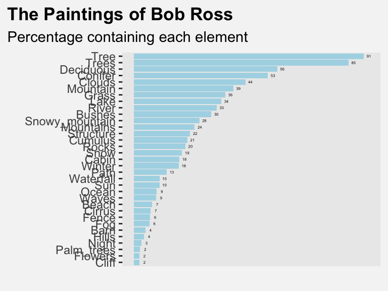

```r
elements_sum %>%
  filter(pct > 2) %>%
  mutate(element = str_to_sentence(element)) %>%
  mutate(element = reorder(element, pct)) %>%

ggplot(aes(x = pct, y = element)) +
  geom_col(fill = "lightblue") +
  geom_text(aes(label = round(pct)),
            size = 1,
            nudge_x = 2) +

  ### eliminate the x axis
  scale_x_continuous(breaks = NULL) +
    # Get rid of the grid and x axis labels, make the background all light gray
  theme(
    panel.grid = element_blank(),
    axis.text.x = element_blank(),
    plot.background = element_rect(fill = "gray96", color = "gray96"),
    plot.title.position = "plot",
    plot.title = element_text(face = "bold")
  ) +

  # Add plot labels and take away axis titles
  labs(
    title = "The Paintings of Bob Ross",
    subtitle = "Percentage containing each element",
    x = "",
    y = ""
  )
```

## New Data

- Read in the file with the colors used for each painting.

```r
painting_colors = read_csv("../../data/bob_ross_paintings.csv")

nrow(painting_colors)
```

```
## [1] 403
```

### Visualize the number of colors

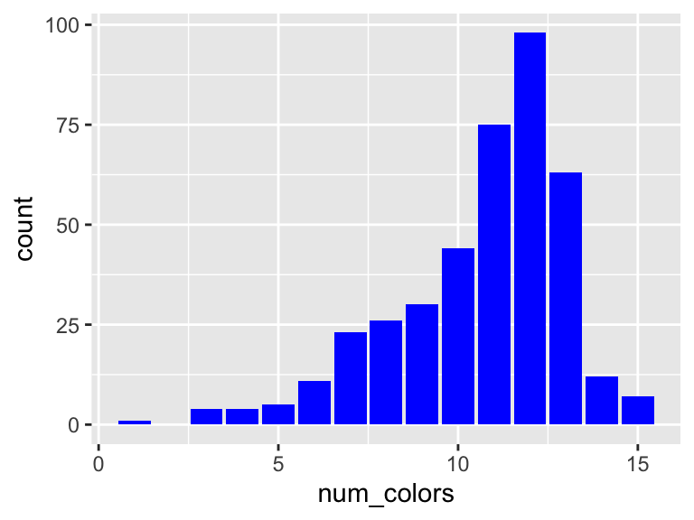

```r
ggplot(painting_colors, aes(x = num_colors)) +
  geom_bar(fill = "blue")
```

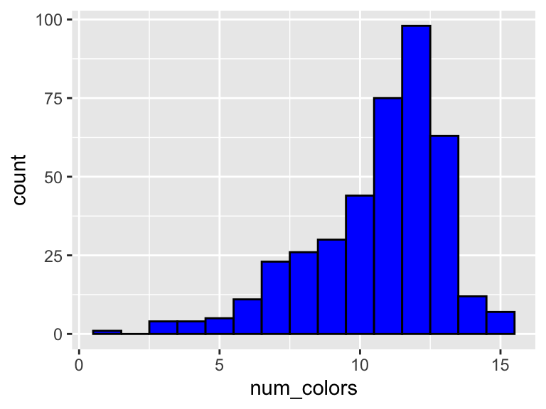

```r
ggplot(painting_colors, aes(x = num_colors)) +
  geom_histogram(center = 0, binwidth = 1,
                 fill = "blue", color = "black")
```

- What’s going on with the painting with one color?

```r
outlier = painting_colors %>%
  filter(num_colors == 1)
```

- We see one painting by a guest artist has only one color and is quite different from the others by Bob Ross himself.

### Join our two data sets

Unlike in the notes, we join the two data sets to keep only those by Bob Ross.

- We eliminate some columns we do not want.

```r
## keep the columns of painting_colors that we want to retain
pc = painting_colors %>%
  select(painting_title, season, episode, num_colors, Black_Gesso:Alizarin_Crimson)


## Note the usage of str_sub() to extract sub strings by position in each value in EPISODE

elements = elements %>%
#  select(-season) %>%
  mutate(season = as.numeric(str_sub(EPISODE, 2, 3)),
         episode = as.numeric(str_sub(EPISODE, 5, 6))) %>%
  relocate(season, episode, .after = EPISODE)

ross = elements %>%
  left_join(pc, by = join_by(season, episode)) %>%
  relocate(painting_title, .after = TITLE) %>%
  relocate(num_colors, .after = painting_title) %>%
  rename(ID = EPISODE) %>%
  select(-TITLE)

dim(ross)
```

```
## [1] 381  71
```

## Inference

### CI for the population proportion of paintings with a structure.

```r
ross %>%
  summarize(n = n(),
            x = sum(STRUCTURE),
            phat = x/n)
```

```
## # A tibble: 1 × 3
##       n     x  phat
##   <int> <dbl> <dbl>
## 1   381    84 0.220
```

### 95% CI for p

```r
x = 84
n = 381

n_tilde = n + 4
p_tilde = (x+2) / n_tilde
p_tilde
```

```
## [1] 0.2233766
```

```r
z_crit = qnorm(0.975)
z_crit
```

```
## [1] 1.959964
```

```r
se = sqrt( p_tilde * (1 - p_tilde) / n_tilde)
se
```

```
## [1] 0.02122725
```

```r
ci = p_tilde + c(-1,1) * z_crit * se
ci
```

```
## [1] 0.1817720 0.2649813
```

```r
round(ci, 3)
```

```
## [1] 0.182 0.265
```

> We are 95% confident that the proportion of Bob Ross paintings with a manmade structure in the imaginary world where the series never ended is between 18.2% and 26.5%.

### Hypothesis Test

- Still assume the binomial model, $X \sim \text{Binomial}(381, p)$.

#### State Hypotheses

$H_0: p = 0.2$  
$H_a: p \neq 0.2$

#### Test Statistic

$X$

#### Null Distribution of $X$

- If $H_0$ is true, then
  - $X \sim \text{Binomial}(381, 0.2)$
  - $\mu = 381 \times 0.2 = 76.2 = 76.2$

#### p-value

- 84 is 7.8 (= 84 - 76.2) above the mean
- The same distance below the mean is 76.2 - 7.8 = 68.4
- The p-value is $P(X \ge 84) + P(X \le 68)$.

```r
1 - pbinom(83, 381, 0.2) + pbinom(68, 381, 0.2)
```

```
## [1] 0.3364916
```

#### Interpret

> There is lack of evidence that the population proportion of paintings with a manmade structure is different from 0.2 (p-value = 0.336, two-sided binomial test)

## Difference in proportions

### Different Test than the notes

Population 1 = Bob Ross paintings that include grass Population 2 = Bob Ross paintings that do not include grass

$p_1$ is the proportion in population 1 (with grass) with a man-made structure

$p_2$ is the proportion in population 2 with a man-made structure

#### Summary Statistics

```r
ross_sum = ross %>%
  summarize(n1 = sum(GRASS),
            n2 = n() - n1,
            x1 = sum(GRASS*STRUCTURE),
            x2 = sum((1 - GRASS) * STRUCTURE),
            phat1 = x1/n1,
            phat2 = x2/n2)

ross_sum
```

```
## # A tibble: 1 × 6
##      n1    n2    x1    x2 phat1 phat2
##   <dbl> <dbl> <dbl> <dbl> <dbl> <dbl>
## 1   137   244    23    61 0.168  0.25
```

> Test if the population proportions of paintings with a structure differ between paintings with grass or without grass.

### State Hypotheses

$H_0: p_1 = p_2$

$H_a: p_1 \neq p_2$

### Test Statistic

- z is standard normal
- p-value is area in two tails
- **Note that we pool the data for a single numerical estimate to use for both p1 and p2 when computing the SE**

$$z = \frac{(\hat{p}_1 - \hat{p}_2) - 0}{\text{SE}}$$

```r
ross_sum %>%
  summarize(
    p_pooled = (x1 + x2) / (n1 + n2),
    se = sqrt( p_pooled * (1 - p_pooled) / n1 +
               p_pooled * (1 - p_pooled) / n2 ),
    z = (phat1 - phat2) / se,
    pvalue = 2*pnorm(-abs(z))
  )
```

```
## # A tibble: 1 × 4
##   p_pooled     se     z pvalue
##      <dbl>  <dbl> <dbl>  <dbl>
## 1    0.220 0.0443 -1.86 0.0635
```

We have a p-value of 0.0.64.

> There is insufficient evidence to conclude that there is a difference in the population proportion of Bob Ross paintings that contain a man-made structure between painting with and without grass (p = 0.064, two-sided z-test for differences in population proportions).

## Inference for a single mean

> Estimate the population mean number of colors in Bob Ross paintings
- point estimate $\pm$ critical_quantile $\times$ SE

> Find a 95% CI for $\mu$

```r
ross %>%
  summarize(n = n(),
            xbar = mean(num_colors),
            s = sd(num_colors),
            se = s / sqrt(n),
            t_crit = qt(0.975, n-1),
            me = t_crit*se,
            low = xbar - me,
            high = xbar + me) %>%
  as.data.frame()
```

```
##     n     xbar        s        se   t_crit        me      low     high
## 1 381 10.76115 2.304038 0.1180395 1.966226 0.2320923 10.52906 10.99325
```

### Interpret

> I am 95% confident that the population mean of the number of colors in a Bob Ross painting is between 10.53 and 11.00.

## Difference in Means

mu1 = mean # colors in paintings with grass mu2 = mean # colors in paintings without grass

- use `t.test()`

```r
grass = ross %>%
  filter(GRASS == 1) %>%
  pull(num_colors)

nograss = ross %>%
  filter(GRASS == 0) %>%
  pull(num_colors)

t.test(grass, nograss)
```

```
##
##  Welch Two Sample t-test
##
## data:  grass and nograss
## t = 7.0203, df = 377.15, p-value = 1.036e-11
## alternative hypothesis: true difference in means is not equal to 0
## 95 percent confidence interval:
##  1.039796 1.848860
## sample estimates:
## mean of x mean of y
##  11.68613  10.24180
```

> We are 95% confident that the population mean number of colors in Bob Ross paintings with grass is between 1.04 and 1.85 larger than the mean in paintings without grass.

> There is overwhelming evidence that the mean number of colors in Bob Ross paintings with grass is larger than the mean number in paintings without grass (p = 0, two-sided t-test for difference in means).